# flowAI report

SIgN_GM

## FCS file information

> Input file name: Donor_Kidney_035  
> Number of events: 2640201

## Quality control analysis

### Summary

> The anomalies were removed from: Flow Rate, Flow Signal and Flow Margin  
> Anomalies detected in total: **84.48** %  
> Number of high quality events: 409712

### Flow rate check

> **17.36** % anomalies detected in the flow rate check.

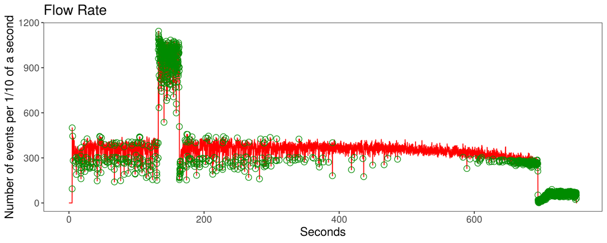

The plot reconstructs the flow rate with a resolution of 1/10 of a second. Anomalies in the flow rate are identified with an algorithm based on the generalied ESD outlier detection method. The anomalies are circled in green.

### Signals acquisition check

> **82.75** % anomalies detected in the signal aquisition check.

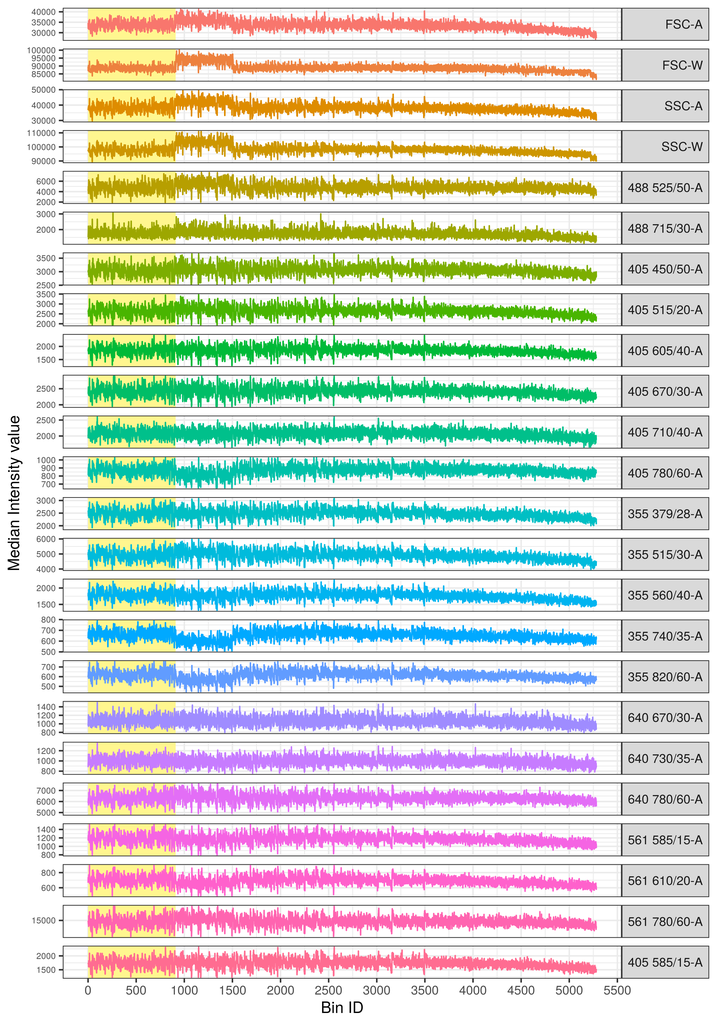

The more stable region selected consistent for all channels is highlighted in yellow. If the removal of outliers has been required before the execution of the changepoint analysis, the detected outliers are cicled in green.

The FCS file was divided in 5281 bins, hence each bin contains 500 event(s). The stable region is located between the bins 1 and 911.

##### More info on the changepoints detected

Changepoints detected in channels with shifts in signal acquisition:

```
##                 1    2    3
## 488 525/50-A 2572
## 488 715/30-A 4120 4803
## 405 450/50-A 2558 4614
## 405 515/20-A 3534 4643
## 405 605/40-A 3524 4651
## 405 670/30-A 3175 4651
## 405 710/40-A 4600
## 405 780/60-A 1723 4652
## 355 379/28-A 3682 4652
## 355 515/30-A 3640 4602
## 355 560/40-A 3697 4493
## 355 740/35-A  911 1535 3682
## 355 820/60-A  915 1575 3682
## 640 670/30-A 4803
## 640 730/35-A 4796
## 640 780/60-A 3178
## 561 585/15-A 2564 4120 4712
## 561 610/20-A 2558 4120 4747
## 561 780/60-A 2590 4712
## 405 585/15-A 3524 4493
```

Channels excluded from the analysis: FSC-A, FSC-W, SSC-A, SSC-W.

### Dynamic range check

> **0.65** % anomalies detected in dynamic range check.

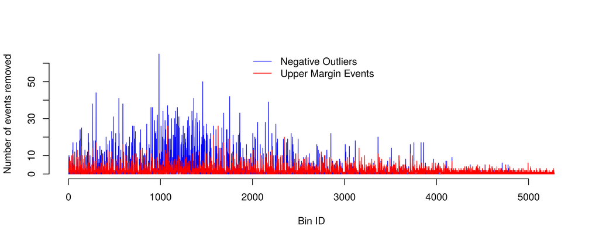

The plot shows where the anomalies occured the most. The x-axis scale is complementary to the one of the signal acquisition plot.

##### More info on the anomalies detected in the dynamic range check

For each channel analyzed, the table shows the number of events that did not pass the dynamic range check:

```
##              lower_range upper_range
## 488 525/50-A        2912         559
## 488 715/30-A        1312         405
## 405 450/50-A        2798         718
## 405 515/20-A         190         937
## 405 605/40-A        1965         424
## 405 670/30-A        1629         281
## 405 710/40-A        1198         163
## 405 780/60-A        2093           7
## 355 379/28-A        1951         353
## 355 515/30-A        1483        1544
## 355 560/40-A        2048         211
## 355 740/35-A        2078          21
## 355 820/60-A        2424           1
## 640 670/30-A        1510          28
## 640 730/35-A        1841          13
## 640 780/60-A        3629         962
## 561 585/15-A        1619         977
## 561 610/20-A        1820         225
## 561 780/60-A        4198        7818
## 405 585/15-A        2124         735
## total_SUM          40822       16382
## total_UNIQUE        8250        9050
```

Channels excluded from the analysis: FSC-A, FSC-W, SSC-A, SSC-W.